# Project_2

Matthew Brown

December 15, 2018

## Background

Car crashes in the United States results in over 30,000 fatalities annually. Kaggle.com hosts a dataset on every car related fatality between 2015 to 2016. It is titled US Traffic Fatality Records. It contains interesting features such as the light condition and the atmospheric condition during each fatal car crash. It would be interesting to see if the two features are associated with respect to the number of car crash fatalities. One would assume that light conditions and weather conditions plays a role in the number of car fatalities. To answer this question, this analysis will look at every car crash fatality for the year 2015.

## Hypothesis

This Analysis will use the Chi-squared Test of Independence to answer the question, is light condition associated with the atmospheric condition with respect to the number of car fatalities?

$H_0:$ Light condition and Atmospheric condition are independent.  
$H_\alpha:$ Light condition and Atmospheric condition are associated.

## Analysis

Below is a graphic that shows how the number of fatalities are related to the Atmospheric condition and the lighting condition. It shows that the majority of car crashes happen when atmospheric conditions are clear. As a side note, this might show that a majority of drivers drive during clear conditions. However that is not the focus of this analysis.

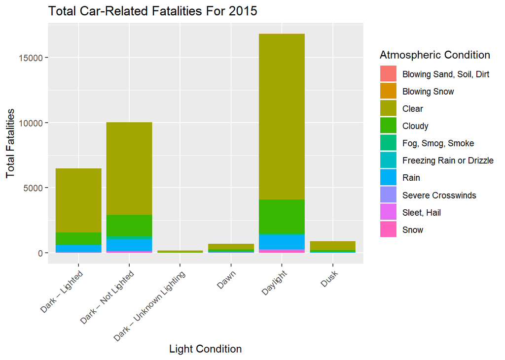

It’s hard to see any association based on this graphic. Another graphic is shown below. It shows how each atmospheric condition makes up the total percentage of fatalities for each category of lighting conditions. For instance, during the night when streets are lighted, clear atmospheric conditions make up about 75% of all traffic fatalities.

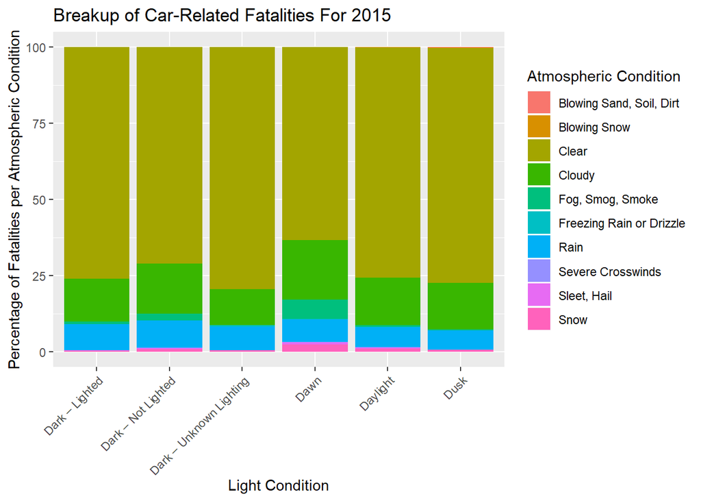

## Test Results

```
##
##  Pearson's Chi-squared test
##
## data:  dat_as_matrix_b
## X-squared = 511.42, df = 45, p-value < 2.2e-16
```

## Test Analysis

The results of the chi-squared Test of Independence is shown below. With a p-value less than 2.2e-16, we can reject the Null-Hypothesis that $H_0:$ The lighting condition and Atmospheric condition are independent in favor of the Alternative Hypothesis that $H_\alpha:$ The lighting condition and Atmospheric condition are associated. The appropriatness of the data is discussed in the Diagnostics section.

## Diagnostics

In the following plotly tables, the rows are as follows  
Row 1: Dark-Lighted  
Row 2: Dark-Not-Lighted  
Row 3: Dark-Unknown-Lighting  
Row 4: Dawn  
Row 5: Daylight  
Row 6: Dusk

### Expected

Although not all counts are greater than 5, the data is appropriate to use because the average of the counts is far greater than 5. The average is shown below.

Table continues below

| Blowing Sand, Soil, Dirt | Blowing Snow | Clear | Cloudy | Fog, Smog, Smoke |
| --- | --- | --- | --- | --- |
| 2.589 | 3.884 | 4808 | 1010 | 81.38 |
| 3.997 | 5.995 | 7421 | 1559 | 125.6 |
| 0.06783 | 0.1017 | 125.9 | 26.46 | 2.132 |
| 0.2833 | 0.4249 | 526 | 110.5 | 8.903 |
| 6.71 | 10.06 | 12458 | 2617 | 210.9 |
| 0.3531 | 0.5297 | 655.7 | 137.7 | 11.1 |

| Freezing Rain or Drizzle | Rain | Severe Crosswinds | Sleet, Hail | Snow |
| --- | --- | --- | --- | --- |
| 4.254 | 494 | 4.254 | 19.42 | 61.96 |
| 6.566 | 762.5 | 6.566 | 29.98 | 95.64 |
| 0.1114 | 12.94 | 0.1114 | 0.5087 | 1.623 |
| 0.4654 | 54.05 | 0.4654 | 2.125 | 6.779 |
| 11.02 | 1280 | 11.02 | 50.32 | 160.5 |
| 0.5801 | 67.37 | 0.5801 | 2.648 | 8.449 |

### Expected greater than 5

Table continues below

| Blowing Sand, Soil, Dirt | Blowing Snow | Clear | Cloudy | Fog, Smog, Smoke |
| --- | --- | --- | --- | --- |
| FALSE | FALSE | TRUE | TRUE | TRUE |
| FALSE | TRUE | TRUE | TRUE | TRUE |
| FALSE | FALSE | TRUE | TRUE | FALSE |
| FALSE | FALSE | TRUE | TRUE | TRUE |
| TRUE | TRUE | TRUE | TRUE | TRUE |
| FALSE | FALSE | TRUE | TRUE | TRUE |

| Freezing Rain or Drizzle | Rain | Severe Crosswinds | Sleet, Hail | Snow |
| --- | --- | --- | --- | --- |
| FALSE | TRUE | FALSE | TRUE | TRUE |
| TRUE | TRUE | TRUE | TRUE | TRUE |
| FALSE | TRUE | FALSE | FALSE | FALSE |
| FALSE | TRUE | FALSE | FALSE | TRUE |
| TRUE | TRUE | TRUE | TRUE | TRUE |
| FALSE | TRUE | FALSE | FALSE | TRUE |

### Average Expected Counts

```
## [1] 584.8
```

### Residuals

Table continues below

| Blowing Sand, Soil, Dirt | Blowing Snow | Clear | Cloudy | Fog, Smog, Smoke |
| --- | --- | --- | --- | --- |
| -1.609 | -1.971 | 1.801 | -3.118 | -3.035 |
| -1.499 | -0.4064 | -3.693 | 2.228 | 9.314 |
| -0.2604 | -0.319 | 0.8069 | -1.256 | -1.46 |
| -0.5322 | -0.6519 | -3.314 | 2.616 | 12.1 |
| 2.042 | 1.241 | 2.095 | -0.1211 | -7.084 |
| 1.089 | 2.02 | 1.029 | -0.3186 | -2.431 |

| Freezing Rain or Drizzle | Rain | Severe Crosswinds | Sleet, Hail | Snow |
| --- | --- | --- | --- | --- |
| -0.6081 | 2.563 | -1.578 | -2.138 | -4.442 |
| -0.2209 | 4.689 | -1.782 | 1.283 | -0.1673 |
| 2.662 | 0.01643 | -0.3338 | -0.7132 | -0.4891 |
| 2.249 | -0.2785 | 0.7836 | 1.973 | 3.926 |
| -0.3081 | -4.81 | 2.403 | 0.2366 | 2.324 |
| 0.5513 | -1.507 | -0.7617 | -1.013 | -0.8427 |

The following graphic shows that indeed, there is an obvious difference in the number of fatalities for Dark-Not Lighted and Daylight. This is for the atmospheric condition of Fog, Smog, Smoke.

Table continues below

| light_condition_name | atmospheric_conditions_1_name | total_fatalities |
| --- | --- | --- |
| Dark – Lighted | Fog, Smog, Smoke | 54 |
| Dark – Not Lighted | Fog, Smog, Smoke | 230 |
| Dawn | Fog, Smog, Smoke | 45 |
| Daylight | Fog, Smog, Smoke | 108 |
| Dusk | Fog, Smog, Smoke | 3 |

| Expected |
| --- |
| 81.38 |
| 125.6 |
| 8.903 |
| 210.9 |
| 11.1 |

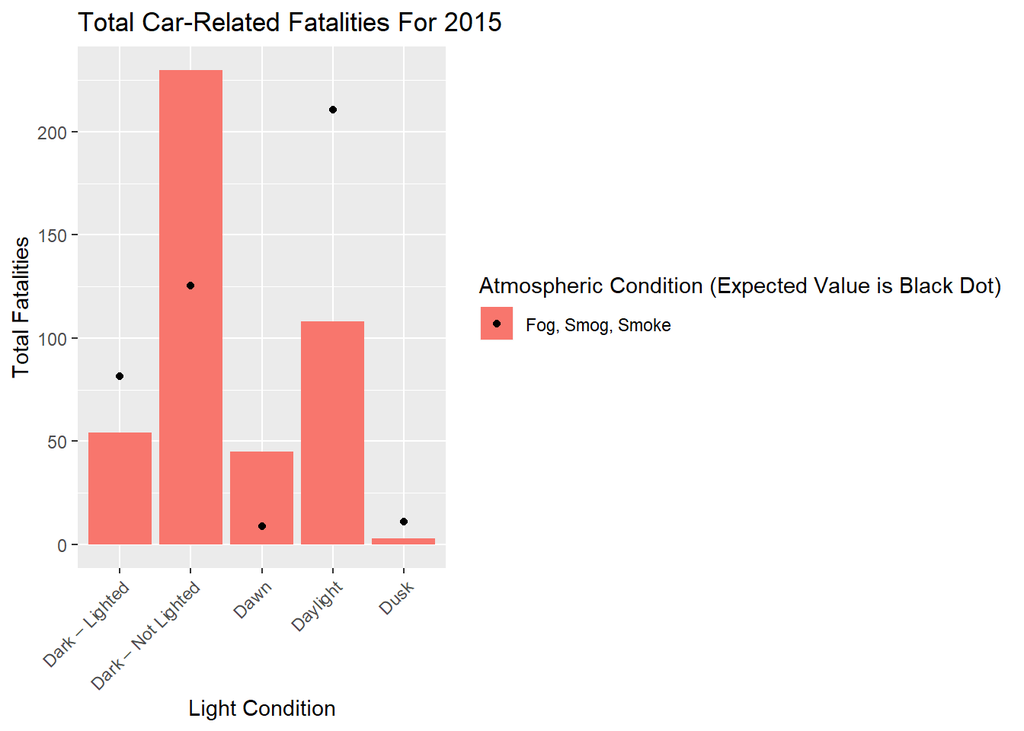